# Introduction to Data Analysis with R

Day 1: Welcome to the workshop

Selina Baldauf

Freie Universität Berlin - Theoretical Ecology

## Welcome

- (Theoretical) Ecology
- Scientific programmer at Freie Universität Berlin
- Research + Coding + Teaching

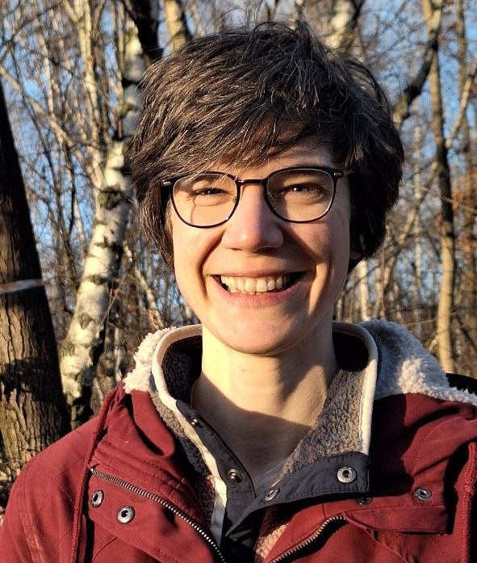

## Workshop topics

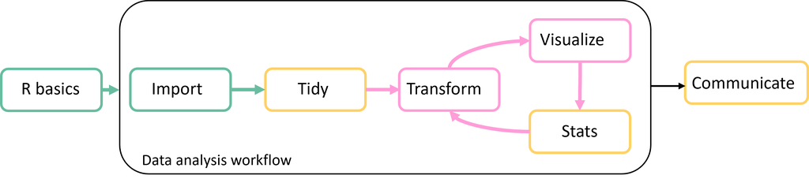

Image adapted from Wickham & Grolemund: [R for Data Science](https://r4ds.had.co.nz/introduction.html)

**Day1** Introduction to R and RStudio and data import

**Day2** Data visualization and transformation with the tidyverse

**Day3** Cleaning data, statistical tests, and reproducible reports with Quarto

**Day 4** Bring your own data

## Schedule

📅 12.10.2026 - 13.10.2026 from 🕘 9 a.m. - 3:30 p.m.  
📅 19.10.2026 - 20.10.2026 from 🕘 9 a.m. - 3:30 p.m.  
🍜 ~ 12 - 1 p.m., ☕ short breaks in between  
📌 Join via the meeting link

## Organization

- Input sessions + Tasks + Discussion/Questions
- Materials on the [workshop’s website](https://selinazitrone.github.io/intro-r-data-analysis/): Presentations, Tasks, Solutions, Additional resources
- Website will stay online after the workshop
- Questions and feedback welcome
- Contact me: selina.baldauf@fu-berlin.de or on Webex (just search for my email there)

## Bring your own data

On the last workshop day, you can **work with your own research data**. I will also provide some **real life data sets** from different topics.

- You really learn R by working with your own data and questions
- Use the methods you learned in the workshop or try new things
- Let me know if there’s something specific you want to do
- Add your name and some details on what you plan to do in this [joint table](https://docs.google.com/spreadsheets/d/1MuINiPjVvZrMRUYboDXdoPwj8daKj88k6K1hnfcoWxQ/edit?usp=sharing)

## Before we get started

Did anyone have problems with the course preparations?

- Download and install R from https://cran.r-project.org
- Download and install RStudio from [https://www.posit.co](https://posit.co/download/rstudio-desktop/)

# Quick round (~10 min)

> Let’s get to know each other

Tell us:

- What’s your **name**?
- What do you **work on**?
- What have you used for **data analysis** so far, if anything (e.g. Excel, SPSS, Python, …)?